# Simple Random Walk

## Introducción

La caminata aleatoria en Z, es la más simple de todas, de ahí su nombre. $X_1$ toma valores en $\{-1; 1\}$, y la caminata comienza en $0$ y está definida para valores en Z. Las probabilidades se denotan como:

$$\begin{equation}
P(X_1 = 1) = P(X_1 = -1) = 1/2
\end{equation}$$

Considerando el caso más general, se tiene que

$$\begin{equation}
P(X_1 = 1) = p \ \ y \ \ P(X_1 = -1) = 1 - p
\end{equation}$$

A este respecto, vamos a obtener la probabilidad de que el caminante se encuentre en la posición $m$ después de $N$ pasos.

Para $m < N$ hay muchas maneras de empezar en $0$ y pasar por $N$ saltos a sitios vecinos más cercanos y terminar en $m$. Sabemos que el número de pasos viene dado por la posición final más el número de pasos a la izquierda, es decir, $n_1 = m + n_2$, y a parte sabemos que $n_1 + n_2 = N$, solucionando para $n_1$ y $n_2$, se tiene

$$\begin{equation}
n_1 = \frac{1}{2} (N + m) \\
n_2 = \frac{1}{2} (N - m) \\
\end{equation}$$

La probabilidad de una secuencia de saltos a la izquierda y a la derecha es el producto de las probabilidades de los saltos individuales. Como los saltos individuales son independientes, todos los caminos que empiezan en $0$ y terminan en $m$ tienen la misma probabilidad global.

$$\begin{equation}
p^{n_1} q^{n_2} = p^{\frac{1}{2} (N + m)} q^{\frac{1}{2} (N + m)}
\end{equation}$$

Esta probabilidad debe multiplicarse por el número total de trayectorias con $n_1$ pasos a la derecha y $n_2$ pasos a la izquierda.

Esto viene dado por el número de formas de poner $n_1$ objetos de $N$ en una caja y $n_2 = N - n_1$ objetos en otra caja. El primer objeto se puede elegir de $N$ maneras, el segundo de $N - 1$ maneras y así sucesivamente. Por lo tanto, el número total de elección de $n_1$ objetos es $N(N - 1)(N - 2)(N - n_1 - 1)$. Pero los $n_1$ objetos son idénticos y pueden disponerse en cualquier orden.

$$\begin{equation}
\frac{N!}{n_1! n_2!} = \frac{N!}{n_1!(N-n_1)!}
\end{equation}$$

La probabilidad de estar en la posición m después de $N$ saltos viene dada, por

$$\begin{equation}
p(m, N) = \frac{N!}{\left(\frac{N+m}{2}\right)! \left(\frac{N-m}{2}\right)!} p^{\frac{1}{2} (N + m)} q^{\frac{1}{2} (N - m)}
\end{equation}$$

Si conocieramos la distribución de probabilidad podríamos obtener todos los momentos. Note que la ecuación anterior se parece mucho a la distribución binomial, si consideramos el número de pasos hacia la derecha como $n = (N +m)/2$ podemos escribir

$$\begin{equation}
p(n, N) = \frac{N!}{n! (N-n)!} p^{n} q^{N - m}
\end{equation}$$

Suponemos que ya conocemos los momentos de la distribución binomial, entonces

$$\begin{equation}
E(n) = NP \\
Var(n) = Npq
\end{equation}$$

Como $n = (N + m)/2! \rightarrow m = 2n - N$, el valor esperado de la posición del caminante después de $N$ pasos viene dada ahora por

$$\begin{eqnarray}
E(m) & = & 2E(n) - N \\
& = & 2Np - N \\
& = & N(2p - 1)
\end{eqnarray}$$

y la varianza viene dada por

$$\begin{eqnarray}
Var[m] & = & 4Var(n) \\
& = & 4Npq
\end{eqnarray}$$

# Caminata aleatoria simple (1-D)

```r
# Function para simular una caminata aleatoria simple
simple.random.walk <- function(n.steps, n.sim, prob.r=0.5){
  n <- n.steps
  a <- prob.r
  # movimiento
  x.left = -1
  x.right = 1
  # iteración
  Sn_mat <- matrix(0,ncol=n+1,nrow=n.sim)
  for(i in 1:n.sim){
    for(j in 2:(n+1)){
      step <- sample(c(x.left,x.right), 1, prob=c(1-a,a), replace=F)
      Sn_mat[i,j] <- Sn_mat[i,j-1] + step
    }
  }
  # names
  names <- sapply(1:(n+1),function(i) paste('step',i,sep=''))
  # data frame
  result_df <- data.frame('sim'=sapply(1:n.sim, function(i) paste('sim',i,sep='')),
                          'Sn'=Sn_mat)
  return(result_df)
}
```

## Ejemplo 1: $p = 0.5$

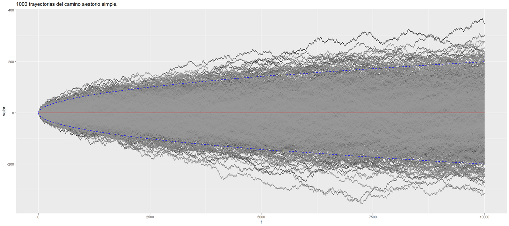

```r
#######  Ejemplo:
n.steps <- 10000   # número de pasos
n.sim <- 1000      # número de trayectorias
p <- 0.5           # probabilidad de moverse a la derecha

df <- simple.random.walk(n.steps, n.sim, prob.r=p)

## trayectorias
df_rw <- df  %>%
  gather(key='t',value='valor',-sim) %>%
  mutate(t = as.numeric(substring(t,4,10))) %>%
  arrange(sim)
# valores teóricos
moments_rw <- data.frame('t'=c(1:n.steps),'p'=p) %>%
  mutate('mean'=t*(p-(1-p)),
         'sd_sup'=mean + 2*sqrt(4*t*p*(1-p)),
         'sd_inf'=mean - 2*sqrt(4*t*p*(1-p)))

p1 <- ggplot(df_rw,aes(x=t,y=valor,color=sim)) +
  geom_line() +
  geom_line(moments_rw, mapping=aes(x=t,y=mean),col='red',size=0.7) +
  geom_line(moments_rw, mapping=aes(x=t,y=sd_sup),col='blue',size=0.7,linetype = "dashed") +
  geom_line(moments_rw, mapping=aes(x=t,y=sd_inf),col='blue',size=0.7,linetype = "dashed") +
  scale_colour_grey(start = 0.2,end = 0.6) +
  theme(legend.position="none") +
  ggtitle(paste(n.sim," trayectorias del camino aleatorio simple.",sep=''))

p1
```

## Ejemplo 2: $p = 0.6$

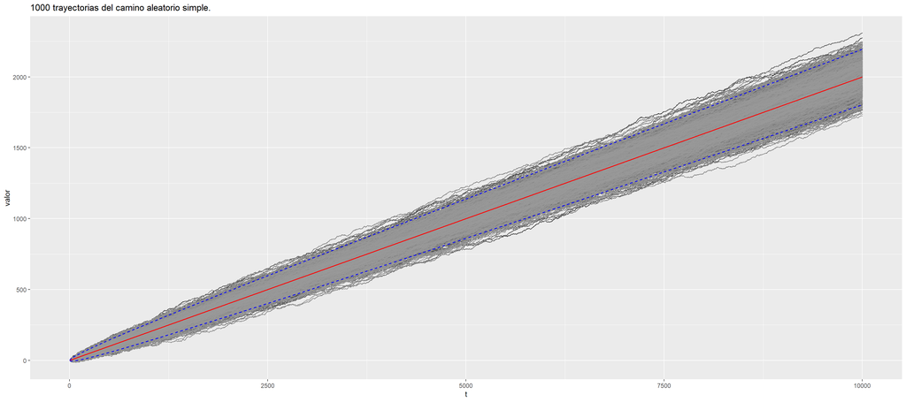

```r
#######  Ejemplo
n.steps <- 10000   # número de pasos
n.sim <- 1000      # número de trayectorias
p <- 0.6           # probabilidad de moverse a la derecha

df <- simple.random.walk(n.steps, n.sim, prob.r=p)

# trayectorias
df_rw <- df  %>%
  gather(key='t',value='valor',-sim) %>%
  mutate(t = as.numeric(substring(t,4,10))) %>%
  arrange(sim)
# valores teóricos
moments_rw <- data.frame('t'=c(1:n.steps),'p'=p) %>%
  mutate('mean'=t*(p-(1-p)),
         'sd_sup'=mean + 2*sqrt(4*t*p*(1-p)),
         'sd_inf'=mean - 2*sqrt(4*t*p*(1-p)))

p2 <- ggplot(df_rw,aes(x=t,y=valor,color=sim)) +
  geom_line() +
  geom_line(moments_rw, mapping=aes(x=t,y=mean),col='red',size=0.7) +
  geom_line(moments_rw, mapping=aes(x=t,y=sd_sup),col='blue',size=0.7,linetype = "dashed") +
  geom_line(moments_rw, mapping=aes(x=t,y=sd_inf),col='blue',size=0.7,linetype = "dashed") +
  scale_colour_grey(start = 0.2,end = 0.6) +
  theme(legend.position="none") +
  ggtitle(paste(n.sim," trayectorias del camino aleatorio simple.",sep=''))

p2
```

## Ejemplo 3: $p = 0.4$

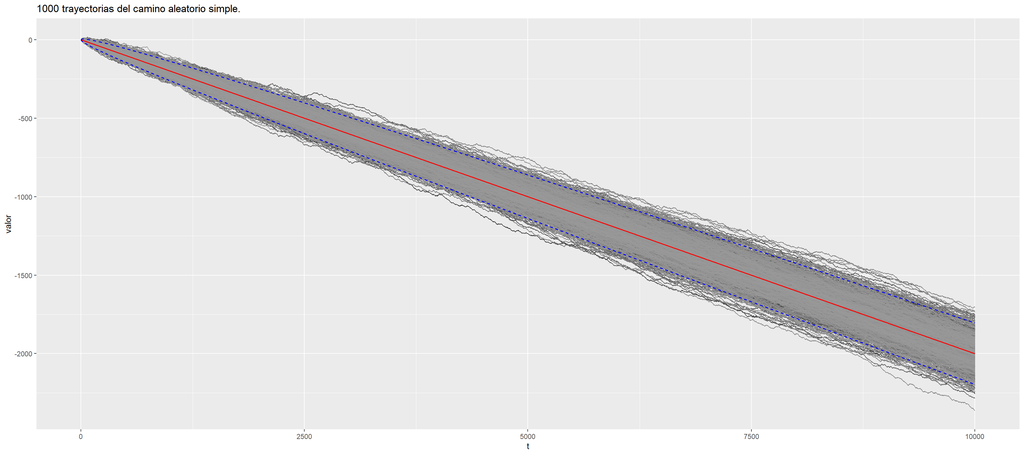

```r
#######  Ejemplo
n.steps <- 10000   # número de pasos
n.sim <- 1000      # número de trayectorias
p <- 0.4           # probabilidad de moverse a la derecha

df <- simple.random.walk(n.steps, n.sim, prob.r=p)

# trayectorias
df_rw <- df  %>%
  gather(key='t',value='valor',-sim) %>%
  mutate(t = as.numeric(substring(t,4,10))) %>%
  arrange(sim)
# valores teóricos
moments_rw <- data.frame('t'=c(1:n.steps),'p'=p) %>%
  mutate('mean'=t*(p-(1-p)),
         'sd_sup'=mean + 2*sqrt(4*t*p*(1-p)),
         'sd_inf'=mean - 2*sqrt(4*t*p*(1-p)))

p3 <- ggplot(df_rw,aes(x=t,y=valor,color=sim)) +
  geom_line() +
  geom_line(moments_rw, mapping=aes(x=t,y=mean),col='red',size=0.7) +
  geom_line(moments_rw, mapping=aes(x=t,y=sd_sup),col='blue',size=0.7,linetype = "dashed") +
  geom_line(moments_rw, mapping=aes(x=t,y=sd_inf),col='blue',size=0.7,linetype = "dashed") +
  scale_colour_grey(start = 0.2,end = 0.6) +
  theme(legend.position="none") +
  ggtitle(paste(n.sim," trayectorias del camino aleatorio simple.",sep=''))

p3
```

# Caminata aleatoria simple (2-D)

```r
#  Caminata aleatoria simple en dos dimensiones
randomWalk2d_plot <- function(base, n.steps){

  df <- base
  df_2d <- df  %>%
    gather(key='t',value='valor',-sim) %>%
    filter(sim == 'sim1' | sim=='sim2') %>%
    spread(sim,valor)  %>%
    mutate(t = as.numeric(substring(t,4,10))) %>%
    arrange(t) %>%
    filter(t <= n.steps)
  b2 <- ggplot(df_2d,aes(x=sim1,y=sim2))+
    geom_point(color="blue") +
    geom_point(df_2d%>%filter(t == 1),mapping=aes(x=sim1,y=sim2),color="green") +
    geom_point(df_2d%>%filter(t == max(t)),mapping=aes(x=sim1,y=sim2),color="red") +
    geom_path() +
    theme(axis.title.x = element_blank(),
          axis.title.y = element_blank(),
          axis.text.x=element_blank(),
          axis.text.y=element_blank(),
          axis.ticks.x=element_blank(),
          axis.ticks.y=element_blank())
  return(b2)
}
```

## Ejemplo 1:

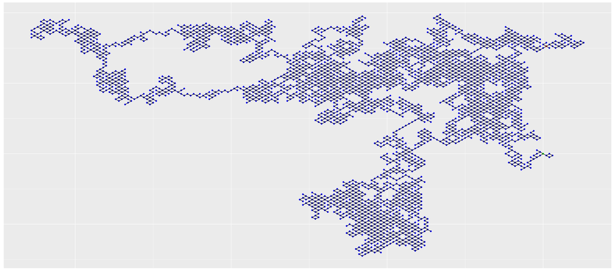

```r
# valores iniciales
n.steps <- 10000   # numero de pasos
n.sim <- 1000      # número de trayectorias
p <- 0.5           # probabilidad de moverse a la derecha
# Gráfico
df <- simple.random.walk(n.steps,n.sim,prob.r=p)
b4 <- randomWalk2d_plot(df, n.steps)
b4
```